# Heat Index-CVD

**Click here to view/hide the code**

```r
timestamp(prefix = "This analysis was rendered on ", suffix = ".")
```

```
This analysis was rendered on Tue Apr 22 17:56:50 2025.
```

## Packages

**Click here to view/hide the code**

```r
## data viz for Heat Index yerawise

pacman::p_load("ggcorrplot","directlabels","pglm", "scales")
suppressPackageStartupMessages(library(tidyverse))
```

### Correlation Analysis

**Click here to view/hide the code**

```r
# Correlation analysis
combined_data <- combined_data |>
        rename(maximum_25=highest_25,
               maximum_975=highest_975,
               minimum_25=lowest_25,
               minimum_975=lowest_975,
               average_25=mean_25,
               average_975=mean_975,
               median_25=median_25,
               median_975=median_975)
correlation_matrix <- cor(combined_data |> select(average_25, average_975, median_25,median_975,mode_25,mode_975,
                                                  maximum_25,maximum_975,
                                                  minimum_25,minimum_975,variation_25,variation_975), method = "pearson")
#correlation_matrix
# visualize as heatmap


# Compute a matrix of correlation p-values
p.mat <- cor_pmat(correlation_matrix)
```

**Click here to view/hide the code**

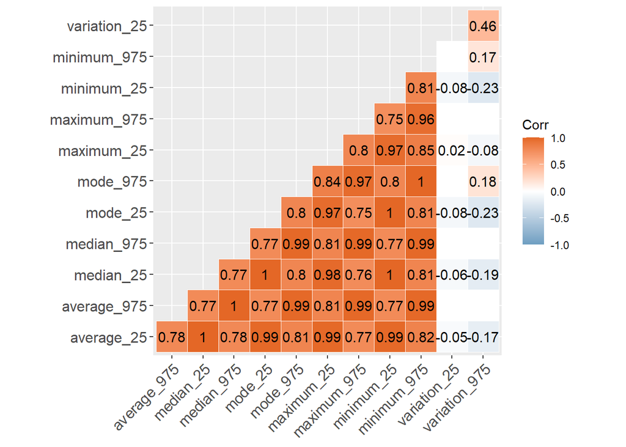

Figure 1: Correlation matrix for Heat Index variables

```r
ggcorrplot(correlation_matrix,
           outline.color = "white",
           type = "lower",
           ggtheme = ggplot2::theme_gray,
           colors = c("#6D9EC1", "white", "#E46726"),
           lab = TRUE,
           p.mat = p.mat,
           insig = "blank")
```

Figure 1 *matrix shows pairwise correlations among various Heat Index metrics (average, median, mode, minimum, maximum, variation) at the 2.5th and 97.5th percentiles. Only statistically significant correlations are displayed, indicating strong associations among several metrics. Based on this analysis, 97.5 percentiles of average heat index and both 2.5 and 97.5 percentiles of the variation in heat index were selected for further analysis. This is to minimize multicollinearity and retain representative variability in the downstream panel regression.*

**Click here to view/hide the code**

Figure 2: Heat Index summaries for India, 2011-2021

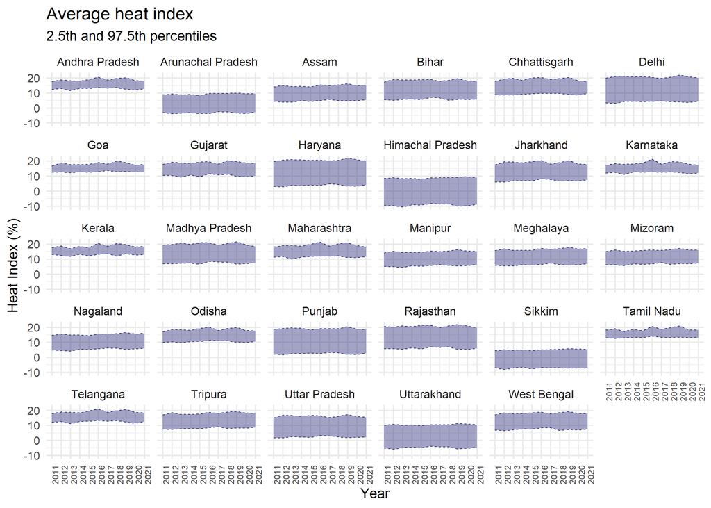

(a) Average Heat Index levels (2.5th and 97.5th percentiles) across Indian states from 2011 to 2021.

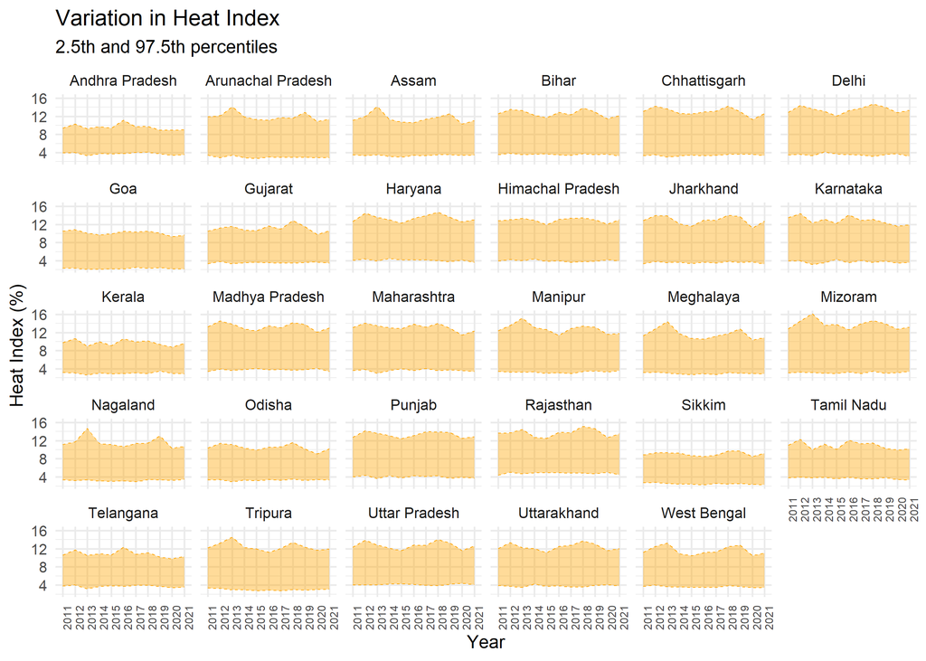

(b) Variation in Heat Index levels (2.5th and 97.5th percentiles) across Indian states from 2011 to 2021.

```r
# averages
combined_data |>
        ggplot(aes(x = factor(Year), group=1)) +
        geom_line(aes(y=average_25),linetype="dashed", color="midnightblue")+
        geom_line(aes(y=average_975),linetype="dashed", color="midnightblue")+
        geom_ribbon(aes(ymin=average_25, ymax=average_975),fill="midnightblue", alpha=0.4)+
        facet_wrap(~State)+
        theme_minimal(base_size = 20)+
        labs(y="Heat Index (%)", x="Year",
             title = "Average heat index",
             subtitle = "2.5th and 97.5th percentiles")+
        theme(axis.text.x = element_text(angle = 90, hjust = 1, size = 12))

# variation

combined_data |>
        ggplot(aes(x = factor(Year), group=1)) +
        geom_line(aes(y=variation_25),linetype="dashed", color="orange")+
        geom_line(aes(y=variation_975),linetype="dashed", color="orange")+
        geom_ribbon(aes(ymin=variation_25, ymax=variation_975),fill="orange", alpha=0.4)+
        facet_wrap(~State)+
        theme_minimal(base_size = 20)+
        labs(y="Heat Index (%)", x="Year",
             title = "Variation in Heat Index",
             subtitle = "2.5th and 97.5th percentiles")+
        theme(axis.text.x = element_text(angle = 90, hjust = 1, size = 12))
```

Figure 2 (a) *illustrates the trends in the 2.5th and 97.5th percentiles of daily Heat Index for each year across Indian states from 2011 to 2021.*

Figure 2 (b) *shows the variation in the 2.5th and 97.5th percentiles of daily Heat Index for each year across Indian states from 2011 to 2021. The shaded areas represent the range between the 2.5th and 97.5th percentiles, indicating the variability in Heat Index levels across states over time.*

**Click here to view/hide the code**

```r
## daly

model_CVD_DALY_avg25 <- pglm(CVD_DALY ~ average_25,
                                   data = combined_data,
                                   family = poisson,
                                   model = "within",
                                   index = c("State", "Year"))
summary(model_CVD_DALY_avg25)
irr_avg25_DALY<- exp(coef(model_CVD_DALY_avg25))
irr_avg25_DALY
irr_lci_avg25_DALY <- exp(confint(model_CVD_DALY_avg25)[, 1])
irr_uci_avg25_DALY <- exp(confint(model_CVD_DALY_avg25)[, 2])
irr_lci_avg25_DALY
irr_uci_avg25_DALY



model_CVD_DALY_avg975 <- pglm(CVD_DALY ~ average_975,
                                    data = combined_data,
                                    family = poisson,
                                    model = "within",
                                    index = c("State", "Year"))
summary(model_CVD_DALY_avg975)
irr_avg975_DALY <- exp(coef(model_CVD_DALY_avg975))
irr_avg975_DALY
irr_lci_avg975_DALY  <- exp(confint(model_CVD_DALY_avg975)[, 1])
irr_uci_avg975_DALY  <- exp(confint(model_CVD_DALY_avg975)[, 2])
irr_lci_avg975_DALY
irr_uci_avg975_DALY


model_CVD_DALY_var25 <- pglm(CVD_DALY ~ variation_25,
                                   data = combined_data,
                                   family = poisson,
                                   model = "within",
                                   index = c("State", "Year"))
summary(model_CVD_DALY_var25)
irr_var25_DALY<- exp(coef(model_CVD_DALY_var25))
irr_var25_DALY
irr_lci_var25_DALY <- exp(confint(model_CVD_DALY_var25)[, 1])
irr_uci_var25_DALY <- exp(confint(model_CVD_DALY_var25)[, 2])
irr_lci_var25_DALY
irr_uci_var25_DALY



model_CVD_DALY_var975 <- pglm(CVD_DALY ~ variation_975,
                                    data = combined_data,
                                    family = poisson,
                                    model = "within",
                                    index = c("State", "Year"))
summary(model_CVD_DALY_var975)
irr_var975_DALY <- exp(coef(model_CVD_DALY_var975))
irr_var975_DALY
irr_lci_var975_DALY  <- exp(confint(model_CVD_DALY_var975)[, 1])
irr_uci_var975_DALY  <- exp(confint(model_CVD_DALY_var975)[, 2])
irr_lci_var975_DALY
irr_uci_var975_DALY

## yld

model_CVD_YLD_avg25 <- pglm(CVD_YLD ~ average_25,
                                   data = combined_data,
                                   family = poisson,
                                   model = "within",
                                   index = c("State", "Year"))
summary(model_CVD_YLD_avg25)
irr_avg25_YLD <- exp(coef(model_CVD_YLD_avg25))
irr_avg25_YLD
irr_lci_avg25_YLD <- exp(confint(model_CVD_YLD_avg25)[, 1])
irr_uci_avg25_YLD <- exp(confint(model_CVD_YLD_avg25)[, 2])
irr_lci_avg25_YLD
irr_uci_avg25_YLD



model_CVD_YLD_avg975 <- pglm(CVD_YLD ~ average_975,
                                    data = combined_data,
                                    family = poisson,
                                    model = "within",
                                    index = c("State", "Year"))
summary(model_CVD_YLD_avg975)
irr_avg975_YLD <- exp(coef(model_CVD_YLD_avg975))
irr_avg975_YLD
irr_lci_avg975_YLD  <- exp(confint(model_CVD_YLD_avg975)[, 1])
irr_uci_avg975_YLD  <- exp(confint(model_CVD_YLD_avg975)[, 2])
irr_lci_avg975_YLD
irr_uci_avg975_YLD

model_CVD_YLD_var25 <- pglm(CVD_YLD ~ variation_25,
                                   data = combined_data,
                                   family = poisson,
                                   model = "within",
                                   index = c("State", "Year"))
summary(model_CVD_YLD_var25)
irr_var25_YLD<- exp(coef(model_CVD_YLD_var25))
irr_var25_YLD
irr_lci_var25_YLD <- exp(confint(model_CVD_YLD_var25)[, 1])
irr_uci_var25_YLD <- exp(confint(model_CVD_YLD_var25)[, 2])
irr_lci_var25_YLD
irr_uci_var25_YLD

model_CVD_YLD_var975 <- pglm(CVD_YLD ~ variation_975,
                                    data = combined_data,
                                    family = poisson,
                                    model = "within",
                                    index = c("State", "Year"))
summary(model_CVD_YLD_var975)
irr_var975_YLD <- exp(coef(model_CVD_YLD_var975))
irr_var975_YLD
irr_lci_var975_YLD  <- exp(confint(model_CVD_YLD_var975)[, 1])
irr_uci_var975_YLD  <- exp(confint(model_CVD_YLD_var975)[, 2])
irr_lci_var975_YLD
irr_uci_var975_YLD

## YLL

model_CVD_YLL_avg25 <- pglm(CVD_YLL ~ average_25,
                                   data = combined_data,
                                   family = poisson,
                                   model = "within",
                                   index = c("State", "Year"))
summary(model_CVD_YLL_avg25)
irr_avg25_YLL <- exp(coef(model_CVD_YLL_avg25))
irr_avg25_YLL
irr_lci_avg25_YLL <- exp(confint(model_CVD_YLL_avg25)[, 1])
irr_uci_avg25_YLL <- exp(confint(model_CVD_YLL_avg25)[, 2])
irr_lci_avg25_YLL
irr_uci_avg25_YLL



model_CVD_YLL_avg975 <- pglm(CVD_YLL ~ average_975,
                                    data = combined_data,
                                    family = poisson,
                                    model = "within",
                                    index = c("State", "Year"))
summary(model_CVD_YLL_avg975)
irr_avg975_YLL <- exp(coef(model_CVD_YLL_avg975))
irr_avg975_YLL
irr_lci_avg975_YLL  <- exp(confint(model_CVD_YLL_avg975)[, 1])
irr_uci_avg975_YLL  <- exp(confint(model_CVD_YLL_avg975)[, 2])
irr_lci_avg975_YLL
irr_uci_avg975_YLL

model_CVD_YLL_var25 <- pglm(CVD_YLL ~ variation_25,
                                   data = combined_data,
                                   family = poisson,
                                   model = "within",
                                   index = c("State", "Year"))
summary(model_CVD_YLL_var25)
irr_var25_YLL<- exp(coef(model_CVD_YLL_var25))
irr_var25_YLL
irr_lci_var25_YLL <- exp(confint(model_CVD_YLL_var25)[, 1])
irr_uci_var25_YLL <- exp(confint(model_CVD_YLL_var25)[, 2])
irr_lci_var25_YLL
irr_uci_var25_YLL

model_CVD_YLL_var975 <- pglm(CVD_YLL ~ variation_975,
                                    data = combined_data,
                                    family = poisson,
                                    model = "within",
                                    index = c("State", "Year"))
summary(model_CVD_YLL_var975)
irr_var975_YLL <- exp(coef(model_CVD_YLL_var975))
irr_var975_YLL
irr_lci_var975_YLL  <- exp(confint(model_CVD_YLL_var975)[, 1])
irr_uci_var975_YLL  <- exp(confint(model_CVD_YLL_var975)[, 2])
irr_lci_var975_YLL
irr_uci_var975_YLL
```

[output not shown]